# POLISCI 9590 - Lab2: Summary Statistics and ggplot2

William Poirier

2025-09-24

## 00. What we’ll be doing:

0. Review;
1. Summary Statistics;
2. ggplot2.

## 0. Review

- `R` is a language `RStudio` is where we write it.
- Directories are how your computer organizes files.
- Change the working directory using `setwd()`
- Data is `R` has a few basic form: 1) Vectors, 2) Matrices, 3) Data Frames, 4) Lists.
- Data in `R` has a few basic classes: 1) Numeric; 2) Integer; 3) Character; 4) Logical; 5) Factor.
- The pipe `|>` is used between operations to take the output of what comes before and use it as the input of what comes next.
- Indexing (extracting a specific element of an object) can be done using:
  - `[i]` with vectors (one dimension);
  - `[i,j]` with matrices or data frames (two dimensions, row number i and column number j);
  - `mydf$aVariableName` in data frames, extracts the column of the corresponding name.
- You can change the structure of you data frame using different functions from `dplyr`:
  - `select()`: which columns do you want;
  - `rename()`: change name of a column;
  - `mutate()`: add a new variable;
  - `filter()`: which rows do you want (based on a condition).

### 0.1 Last week’s exercises

1. What is the `fertility` rate and `ppgdp` of the 4 country with highest female life expectancy (`lifeExpF`)? Make sure you are using no country where `region` is missing.

```r
library(tidyverse)
data(UN, package="carData")
UN <- as_tibble(UN,rownames="country")

UN |>
  drop_na(region) |>
  arrange(-lifeExpF) |>
  select(country,fertility,ppgdp) |>
  slice_head(n=4)
```

```
## # A tibble: 4 × 3
##   country   fertility  ppgdp
##   <chr>         <dbl>  <dbl>
## 1 Japan          1.42 43141.
## 2 Hong Kong      1.14 31824.
## 3 France         1.99 39546.
## 4 Spain          1.50 30543.
```

2. What is the `fertility` rate and `ppgdp` of the 2 most urbanised country (`pctUrban`) for each `region`? Make sure you are using no country where `region` is missing.

```r
UN |>
  drop_na(region) |>
  group_by(region) |>
  arrange(-pctUrban) |>
  select(country,fertility,ppgdp) |>
  slice_head(n=2)
```

```
## # A tibble: 15 × 4
## # Groups:   region [8]
##    region        country       fertility  ppgdp
##    <fct>         <chr>             <dbl>  <dbl>
##  1 Africa        Gabon              3.20 12469.
##  2 Africa        Libya              2.41 11321.
##  3 Asia          Hong Kong          1.14 31824.
##  4 Asia          Macao              1.16 49990.
##  5 Caribbean     Anguilla           2    13750.
##  6 Caribbean     Bermuda            1.76 92625.
##  7 Europe        Belgium            1.84 43815.
##  8 Europe        Malta              1.28 19599.
##  9 Latin Amer    Venezuela          2.39 13503.
## 10 Latin Amer    Argentina          2.17  9162.
## 11 North America United States      2.08 46546.
## 12 North America Canada             1.69 46361.
## 13 NorthAtlantic Greenland          2.22 35293.
## 14 Oceania       Nauru              3.3   6190.
## 15 Oceania       Australia          1.95 57119.
```

3. Create a variable called `fertility1000`, the result of this operation `fertility*1000-infantMortality`. What is the highest country on `fertility1000` in each region? Make sure to use only countries where both `fertility` and `infantMortality` are known.

```r
UN |>
  drop_na(fertility,infantMortality) |>
  mutate(fertility1000=fertility*1000-infantMortality) |>
  group_by(region) |>
  arrange(-fertility1000) |>
  slice_head(n=1)
```

```
## # A tibble: 7 × 9
## # Groups:   region [7]
##   country        region group fertility  ppgdp lifeExpF pctUrban infantMortality
##   <chr>          <fct>  <fct>     <dbl>  <dbl>    <dbl>    <dbl>           <dbl>
## 1 Niger          Africa afri…      6.92   358.     55.8       17           85.8
## 2 Timor Leste    Asia   other      5.92   706.     64.2       29           56.5
## 3 Haiti          Carib… other      3.16   613.     63.9       54           58.3
## 4 Iceland        Europe other      2.10 39278      83.8       94            2.06
## 5 Guatemala      Latin… other      3.84  2882.     75.1       50           26.3
## 6 United States  North… oecd       2.08 46546.     81.3       83            6.46
## 7 Marshall Isla… Ocean… other      4.38  3069.     70.6       72           21
## # ℹ 1 more variable: fertility1000 <dbl>
```

## 1. Summary Statistics

There’s a bunch of them:

| Statistic | R function | Formula |
| --- | --- | --- |
| Mean | `mean()` | $\bar Y=\frac{\sum_{i=1}^n Y_i}{n}$ |
| Variance | `var()` | $sd^2=\frac{\sum_{i=1}^n(Y_i-\bar Y)^2}{n-1}$ |
| Standard Deviation | `sd()` | $sd=\sqrt\frac{\sum_{i=1}^n(Y_i-\bar Y)^2}{n-1}$ |
| Median | `median()` | Middle value ($Q_2$) |
| Interquartile Range | `IQR()` | $iqr=Q_3-Q_1$ |
| Minimum | `min()` |  |
| Maximum | `max()` |  |

Usefull functions:

- `summary(myVector)` will give you most of what’s above.
- `DAMisc::sumStats(myVector)` will give you all of what’s above in a formatted table.

### 1.1 Examples

1. What is the average `price` of diamonds in the dataset `diamonds` that ships with the tidyverse?

```r
#### Initialization ####
#install.packages("devtools")
#devtools::install_github("https://github.com/davidaarmstrong/damisc.git")
library(DAMisc)
mean(diamonds$price)
```

```
## [1] 3932.8
```

2. What is the standard deviation of the `carat` of the diamonds?

```r
sd(diamonds$carat)
```

```
## [1] 0.4740112
```

3. What about the variance?

```r
var(diamonds$carat)
```

```
## [1] 0.2246867
```

```r
# You could also do this instead
sd(diamonds$carat)^2
```

```
## [1] 0.2246867
```

4. What if you want all of the statistics for `clarity`?

```r
class(diamonds$clarity)
```

```
## [1] "ordered" "factor"
```

```r
table(diamonds$clarity)
```

```
##
##    I1   SI2   SI1   VS2   VS1  VVS2  VVS1    IF
##   741  9194 13065 12258  8171  5066  3655  1790
```

```r
# Being a factor, summary will not be much help
summary(diamonds$clarity)
```

```
##    I1   SI2   SI1   VS2   VS1  VVS2  VVS1    IF
##   741  9194 13065 12258  8171  5066  3655  1790
```

```r
# Except if you do this
summary(as.numeric(diamonds$clarity))
```

```
##    Min. 1st Qu.  Median    Mean 3rd Qu.    Max.
##   1.000   3.000   4.000   4.051   5.000   8.000
```

```r
# But sumStats does better
sumStats(diamonds, "clarity")
```

```
## # A tibble: 1 × 11
##   variable  mean    sd   iqr   min   q25   q50   q75   max     n   nNA
##   <chr>    <dbl> <dbl> <dbl> <dbl> <dbl> <dbl> <dbl> <dbl> <int> <int>
## 1 clarity   4.05  1.65     2     1     3     4     5     8 53940     0
```

5. What is the mean and standard deviation of the price of diamonds with a clarity of VVS2 and carat between 2.0 and 2.1?

## 2. ggplot2

- ggplot2 is a package from the tidyverse suit, written as part of Hadley Wickham PhD dissertation.
- gg stands for *Grammar of Graphics*.
- It works in **layers**.
- Best ressource [here](https://ggplot2.tidyverse.org/index.html).

General Setup:

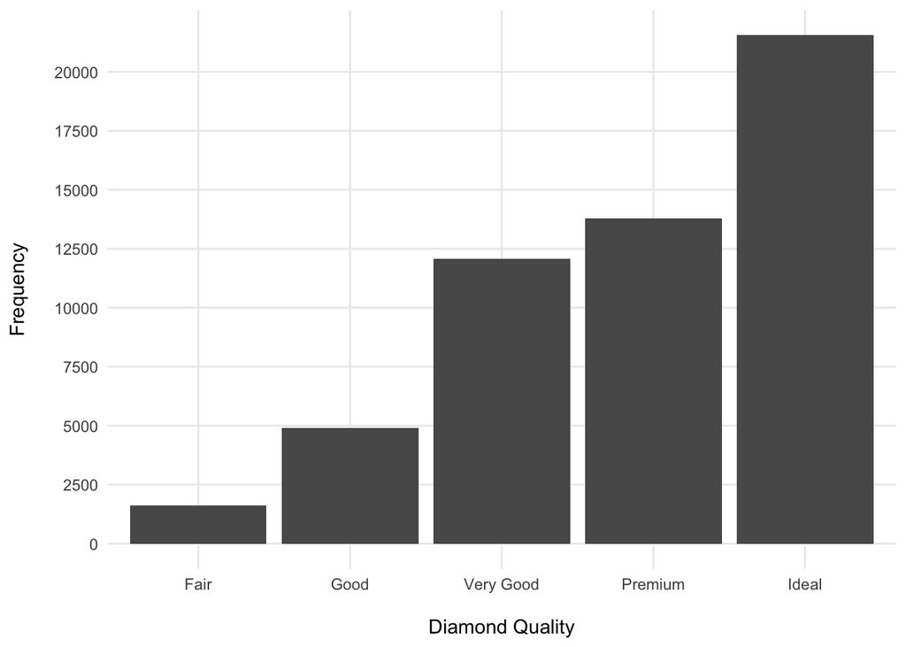

```r
library(tidyverse)

ggplot(diamonds,                                # 1. Data;
       aes(x=cut))+                             # 2. Axis variables;
  geom_bar()+                                   # 3. What you want to draw;
  scale_x_discrete("\nDiamond Quality")+        # 4. Specify x axis text;
  scale_y_continuous("Frequency\n",             # 5. Specify y axis text;
                     breaks=seq(0,20000,2500))+ #
  theme_minimal()+                             # 6. General Style;
  theme(panel.grid.minor = element_blank())     # 7. Specific Style.
```

With these notions, you can be quite creative:

[figure not shown]

Sky is the limit bud!

### 2.1 Examples

1. Using the `diamonds` dataset, create a bar plot of the number of observations for each diamond quality (`cut`). Subset the data to only diamonds above the mean `price` from the dataset.

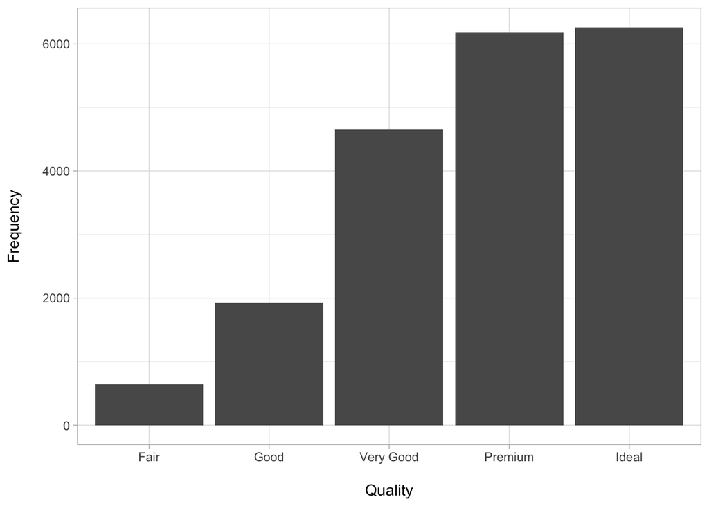

```r
diamonds %>%
  filter(price > mean(diamonds$price)) %>%
  ggplot()+
  geom_bar(aes(x=cut))+
  xlab("\nQuality")+
  ylab("Frequency\n")+
  theme_light()
```

2. Reorder the above from highest to lowest frequency.

```r
# Option 1
diamonds %>%
  filter(price > mean(diamonds$price)) %>%
  mutate(cut_rev=factor(cut,
                        levels=c("Ideal","Premium","Very Good","Good","Fair"))) %>%
  ggplot()+
  geom_bar(aes(x=cut_rev))+
  xlab("\nQuality")+
  ylab("Frequency\n")+
  theme_light()
```

[output not shown]

```r
# Option 2
diamonds %>%
  filter(price > mean(diamonds$price)) %>%
  mutate(ones = 1) %>%
  ggplot(aes(x=reorder(cut,ones,sum,decreasing = T)))+
  geom_bar()+
  xlab("\nQuality")+
  ylab("Frequency\n")+
  theme_light()
```

[output not shown]

```r
# Option 3
diamonds %>%
  filter(price > mean(diamonds$price)) %>%
  group_by(cut) %>%
  summarise(freq=n()) %>%
  ggplot(aes(x=reorder(cut,freq,decreasing = T),y=freq)) +
  geom_col()+
  xlab("\nQuality")+
  ylab("Frequency\n")+
  theme_light()
```

[output not shown]

3. Plot a histogram of `price` per `cut` of diamonds.

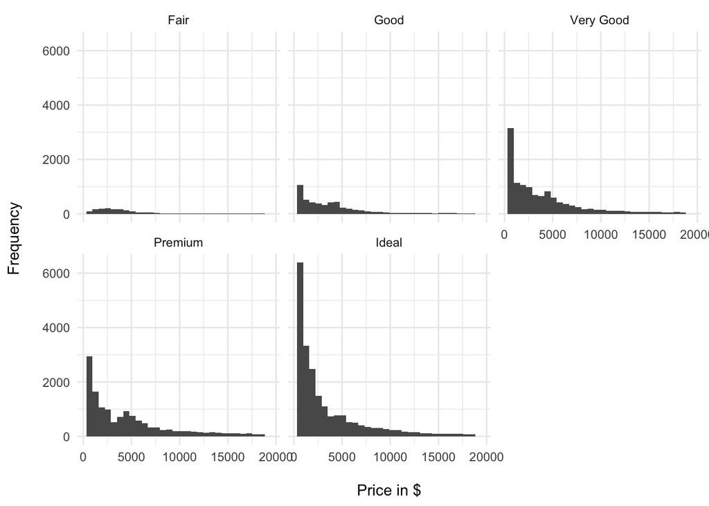

```r
ggplot(diamonds,aes(x=price))+
  geom_histogram()+
  facet_wrap(~cut)+
  xlab("\nPrice in $")+
  ylab("Frequency\n")+
  theme_minimal()
```

4. Arrange the facets above in a single row in order of their respective medians. Make sure the x axis is readable.

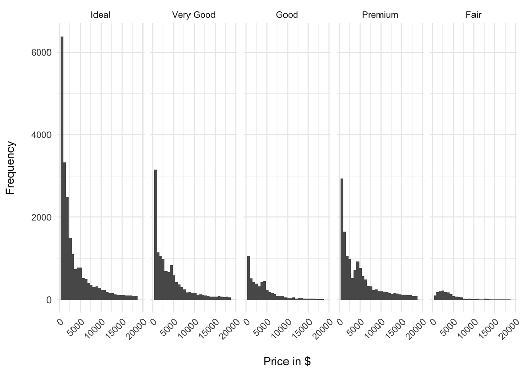

```r
ggplot(diamonds,aes(x=price))+
  geom_histogram()+
  facet_wrap(~reorder(cut,price,median),nrow=1)+
  xlab("\nPrice in $")+
  ylab("Frequency\n")+
  theme_minimal()+
  theme(axis.text.x = element_text(angle=45,hjust=1))
```

5. Plot the average `price` of diamonds per `carat` as they relate to `clarity`

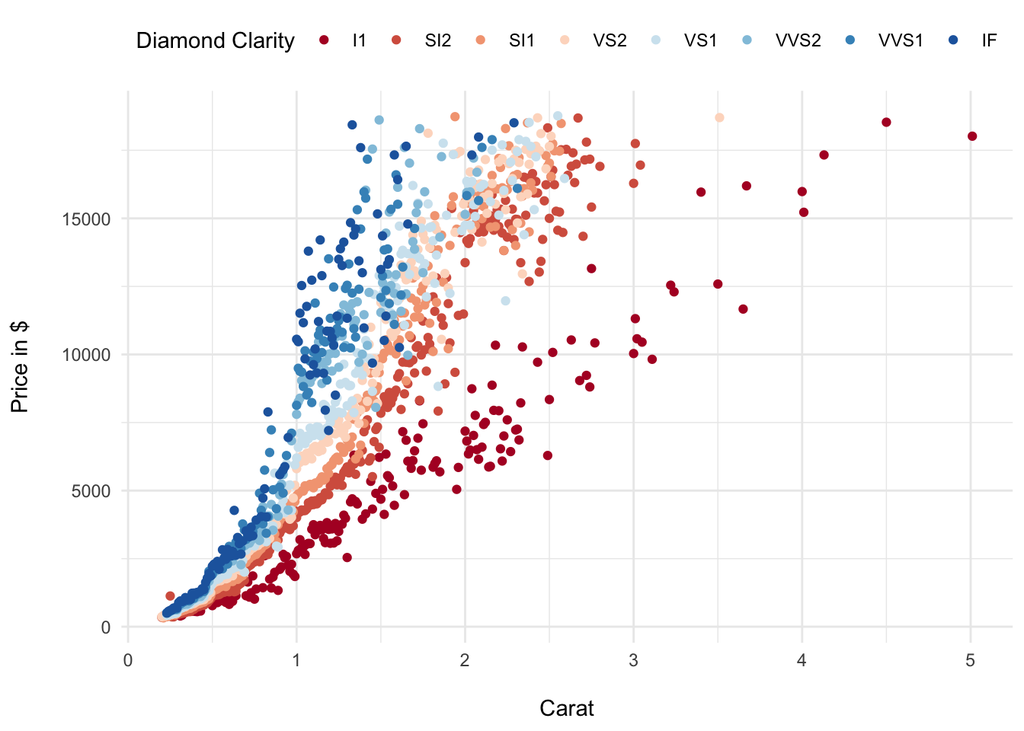

```r
diamonds %>%
  group_by(clarity,carat) %>%
  summarise(averagePrice=mean(price)) %>%
  ggplot(aes(x=carat,y=averagePrice,color=clarity))+
  geom_point()+
  scale_color_brewer("Diamond Clarity",palette = "RdBu")+
  xlab("\nCarat")+
  ylab("Price in $\n")+
  theme_minimal()+
  theme(legend.position = "top")+
  guides(colour = guide_legend(nrow = 1))
```

## 3. Try it yourself

From the `carData::Salaries` data set of 2008-2009 nine-month academic salary for Assistant Professors, Associate Professors and Professors in a college in the U.S., create a graph that presents:

1. The mean salary per years since PhD with regards to sex per discipline.
2. Make sure that the axis, facets and legend are properly named.
3. Rescale the y axis to have salaries in increments of 25000 and the x axis to have years in increments of 5.
4. Make sure the legend is on top of the graph.